# Covid19 Analysis

Maeva Braeckevelt

# Executive summary

The objectif of this analysis is to analyse the pattern of association between registered covid-19 cases and registered number of death du to covi-19 on the 26 october 2020.The data gathered by the Center for Systems Science and Engineering and the World Bank’sites is composed by a few variables, such as the countries, the confirmed cases, the deaths, (both by person), and the population.My sample is on day of analysis compare to a month, a year…

# Introduction

The aim of this project is to analyse the pattern of association between the confirmed case of Covid19 and the death du to. The variables I will use in this analysis are the confirmed case (x) and deaths (y) du to covid and the population of 170 countries on the 26/10/2020. The variable are mesuread by person. The population is all the covid-19 confirmed case and all the death du to it. There are 195 countries in the world, so my sample of 170 is representatif for this point view. However, I just have one record day. That is a bit low and that could be a potential issue for external validity. The quality of my data depend of the acutness of the counting done by every country. We can’t be sure that every countries had the same counting process.

# Observations

To simplify the undertsanding of my analysis, I have decided to drop the counties that have 0 death, it only represent 7% of the data so I will focus on the majority of non-zero values. I decided to convert my cases confirmed and of deaths per 1000 persons, and my population by millions. These conversion will help the clarity of the analysis and give me the possibilty of using the log-tranformation if needed.

# Histogram and summary statitics

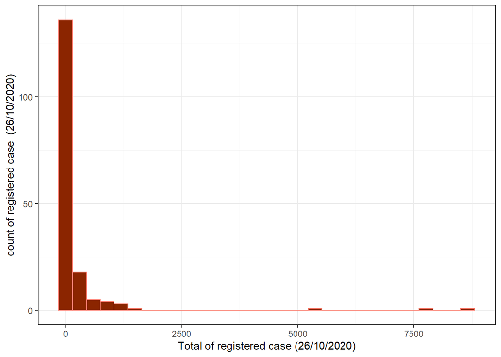

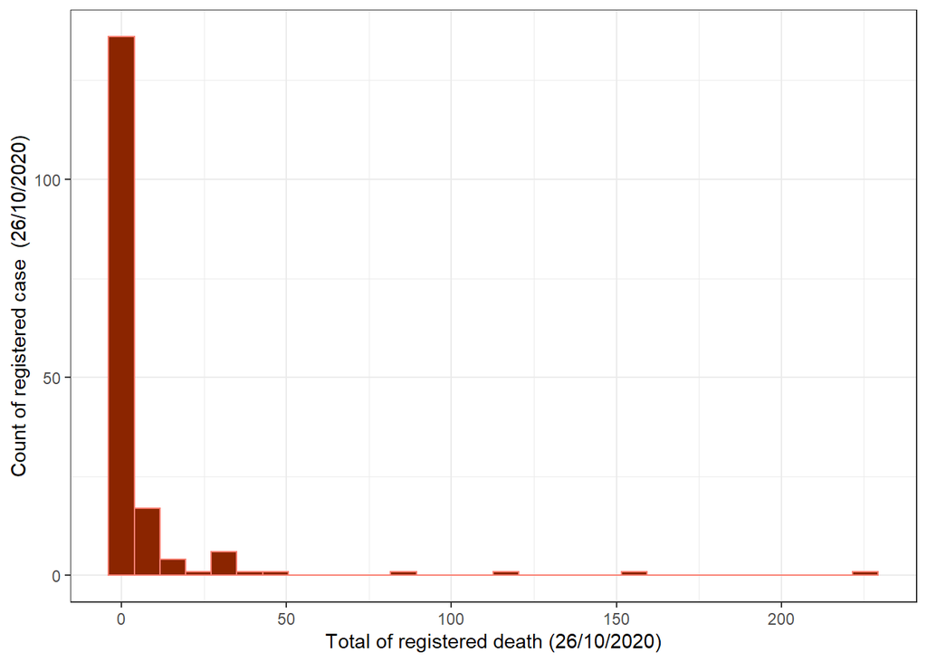

| variable | mean | median | min | max | sd | skew |
| --- | --- | --- | --- | --- | --- | --- |
| Case confirmed | 252.983677 | 27.978 | 0.033 | 8660.088 | 998.89399 | 7.041386 |
| case of death | 6.784735 | 0.431 | 0.001 | 225.458 | 24.59623 | 6.376255 |

I observed some similarities between the two variable : they both are skewed with a right tails and some extrem values. The median of both are significatly smaller than the mean. The majority of the countries have low value. Although, those variable share the same tendancy, the scale is very different between them.

# Transformation of the variables

I investigated the transformation of the variable : level-level (figure A1 in the appendix), log-level (A2), level-log (A3), log-log(A4). I choose to use the fourth model (A4) : use Log transformation for both of my variables. Substantively, it makes sens : both of the variable are affected in multiplicatives ways, the graph itself fits better to interpretation. Statisticaly,the distribution of the variables are skewed with a long right tail, if I take log my transformed variable will appear more symetric and it will reduce the influence of the extrem values. I can easily compare them to each other.

# Modeling

I choose the fourth model (A8) : Weighted linear regression : weight with population. It sounds appropriate that bigger population have a bigger impact on the slope. Please find in the appendix the estimation of the different models, the comparaison and argumentation.

formule : ln_death = -3,39 + 0,95 * ln_confirmed, weights: population

α : -3,39 is the average of ln_death when the confirmed case is one (ln(1)=0) (not meaningfull interpretation) β : the deaths is 0,95 percent higher on average for observation having one percent higher case confirmed

# Appendix

This appendix contains the graphs of the analysis numeroted.

## Investigation of the transformation of the variable

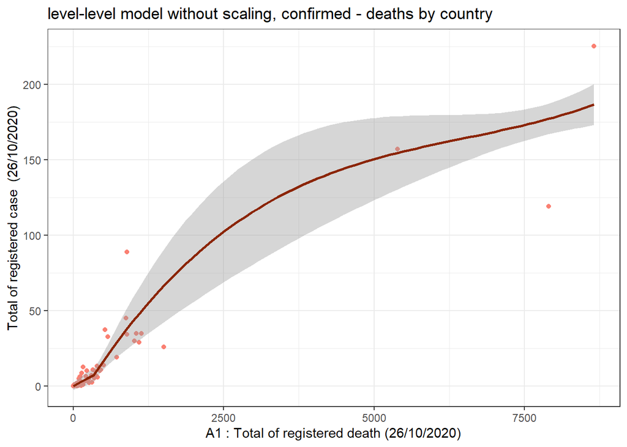

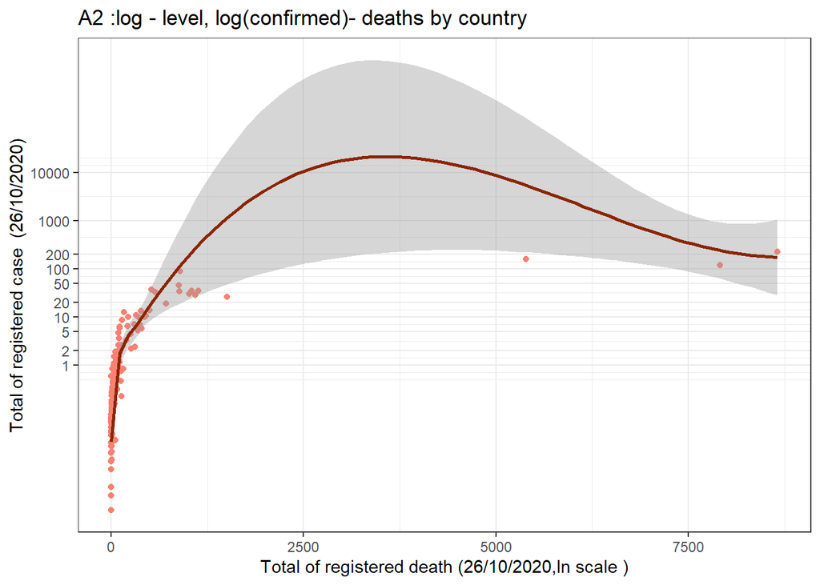

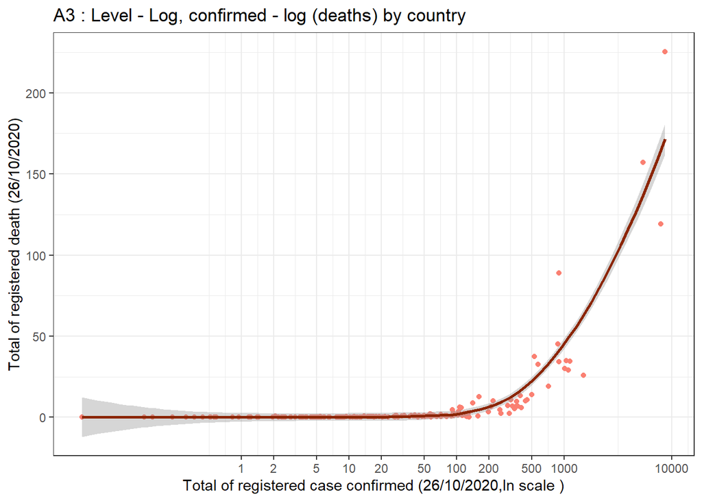

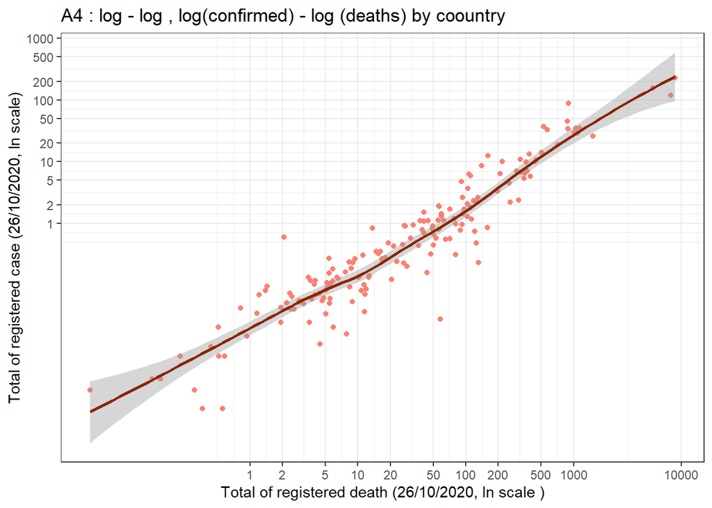

## Estimating different models

I estimated fourth model : Simple linear regression (A5), quadric linear regression (A6), Piecewise linear spline regression (A7)and Weighted linear regression : weight with population (A8).

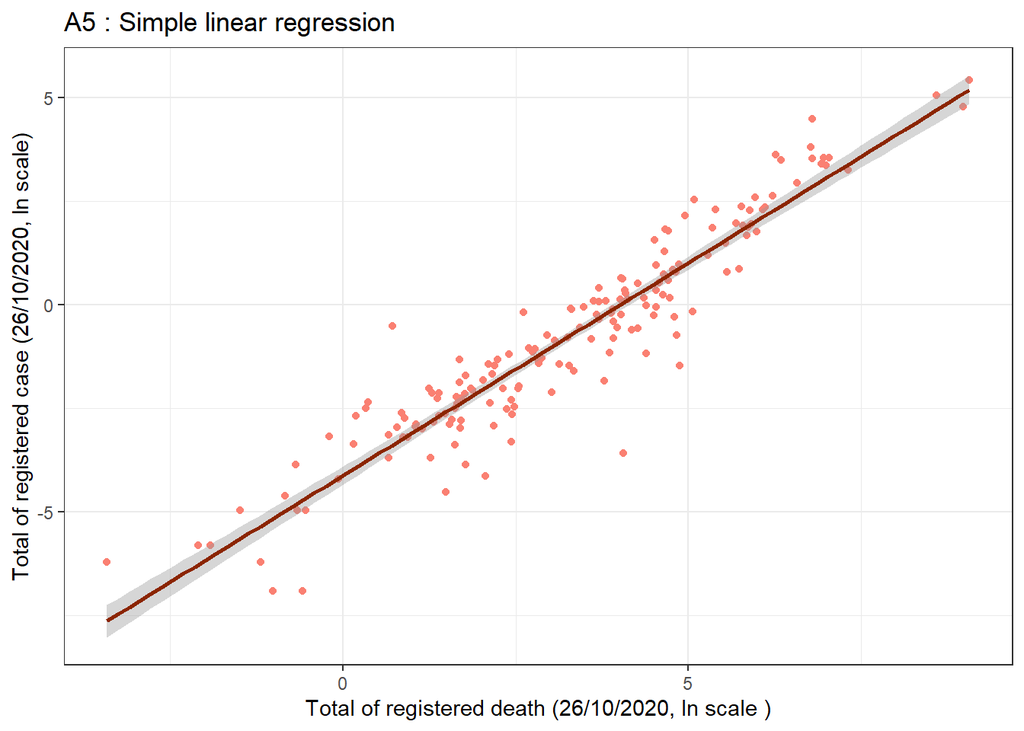

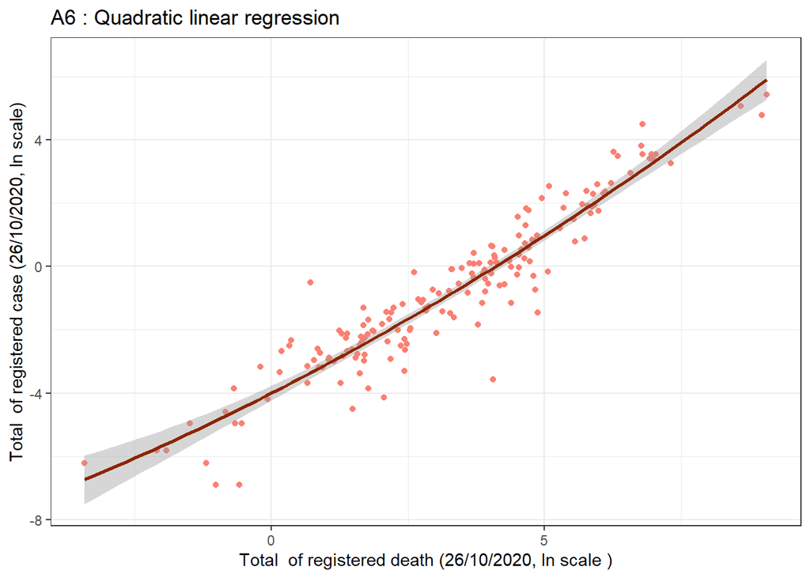

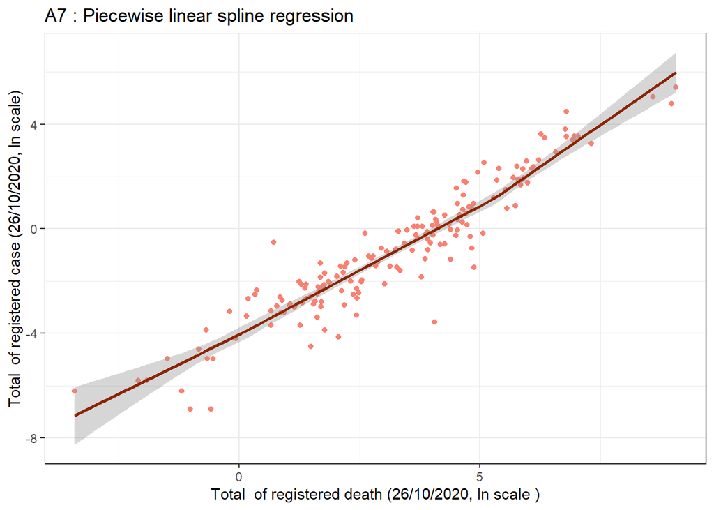

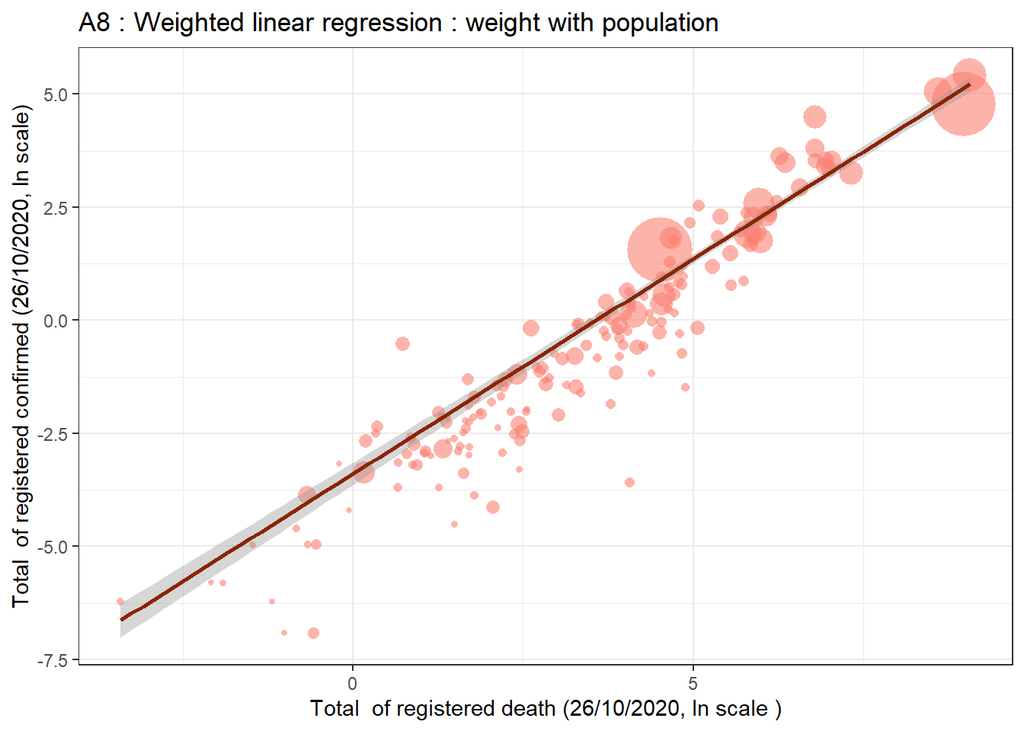